# S&DS 363 Homework 6

Evan Collins, Kelly Farley, Ken Stier

23 April 2021

```r
# clear env
rm(list=ls())

# Load packages
library(car)
library(tidyverse)
library(MASS)
library(DiscriMiner)
library(klaR)
#library(aplpack)
library(fpc)
library(cluster)
library(ape)
library(amap)

# Packages pertinent to Ordination
library(vegan) # eggplant
#library(vegan3d)
library(mgcv)
#library(rgl)
library(dplyr)
library(magrittr)
```

# Contributors

Evan Collins (evan.collins@yale.edu)

Kelly Farley (kelly.farley@yale.edu)

Ken Stier (ken.stier@yale.edu)

# The Dataset

*Raw dataset:* COVID-19 infection and death statistics from U.S. counties (sourced from NYT), combined with economic, education, and population data (sourced from various government agencies) and also survey responses about mask-wearing frequencies (sourced from NYT). 3141 complete observations on 19 metric variables and 6 categorical variables. To avoid any outliers due to population size differences between counties, all variables are scaled as a percentage of population. Variable descriptions can be found [here](http://evancollins.com/variable_descriptions.html).

*Data of relevance for this pset:*

This pset only explores the 67 counties in the best state, Florida.

We look at five continuous variables describing each county: `Always_Wear_Mask_Survey`, `Median_Household_Income_Percent_of_State_Total_2019`, `Percent_Poverty_2019`, `Percent_Adults_Less_Than_HS`, and `Covid_Confirmed_Cases_as_pct`. Note that `Always_Wear_Mask_Survey` and `Covid_Confirmed_Cases_as_pct` were multiplied by 100 to convert the value from a fraction to percent value (like the other variables). This data is stored in `data_ord_base`.

For additional continuous variables, we make an environmental dataset. We look at five additional continuous variables describing each county: `Unemployment_Rate_2019`, `Death_Rate_2019`, `Birth_Rate_2019`, `Civilian_Labor_Force_2019_as_pct`, `Percent_Adults_Bachelors_or_Higher`. Note that `Civilian_Labor_Force_2019_as_pct` was multiplied by 100 to convert the value from a fraction to percent value (like the other variables). This data is stored in `data_ord_env`.

```r
# Process raw dataset as we have done in preceding psets

raw <- read.csv("https://evancollins.com/covid_and_demographics.csv")

# create categorical variables: rural-urban code (3 levels), region (4 variables)

# log transformations of our continuous variables
raw$logMedian_Household_Income_2019 <- log(raw$Median_Household_Income_2019 + 0.0001)
raw$logPercent_Poverty_2019 <- log(raw$Percent_Poverty_2019 + 0.0001)
raw$logCovid_Confirmed_Cases_as_pct <- log(raw$Covid_Confirmed_Cases_as_pct + 0.0001)
```

```r
# Base dataset of interest for this pset - data_ord_base
data_ord <- raw[raw$State_Name=="Florida", ]
data_ord <- data_ord[, c(2, 9, 12, 13, 14, 22)]

data_ord_base <- data_ord
data_ord_base$Covid_Confirmed_Cases_as_pct <- 100*data_ord_base$Covid_Confirmed_Cases_as_pct
data_ord_base$Always_Wear_Mask_Survey <- 100*data_ord_base$Always_Wear_Mask_Survey

data_ord_base1 <- data_ord_base
data_ord_base <- data_ord_base1[,-1]
rownames(data_ord_base) <- data_ord_base1[,1] # rownames are county names

dim(data_ord_base)
```

```
## [1] 67  5
```

```r
head(data_ord_base)
```

```
##          Always_Wear_Mask_Survey
## Alachua                     75.1
## Baker                       44.2
## Bay                         54.8
## Bradford                    38.1
## Brevard                     60.7
## Broward                     79.1
##          Median_Household_Income_Percent_of_State_Total_2019
## Alachua                                                 84.3
## Baker                                                  102.1
## Bay                                                     98.6
## Bradford                                                80.3
## Brevard                                                 97.3
## Broward                                                103.8
##          Percent_Poverty_2019 Percent_Adults_Less_Than_HS
## Alachua                  18.4                         7.6
## Baker                    14.9                        15.5
## Bay                      12.1                         9.7
## Bradford                 21.0                        21.7
## Brevard                   9.4                         8.0
## Broward                  12.3                        11.2
##          Covid_Confirmed_Cases_as_pct
## Alachua                      7.984597
## Baker                       10.838754
## Bay                         10.043788
## Bradford                     9.712422
## Brevard                      5.189537
## Broward                      9.243293
```

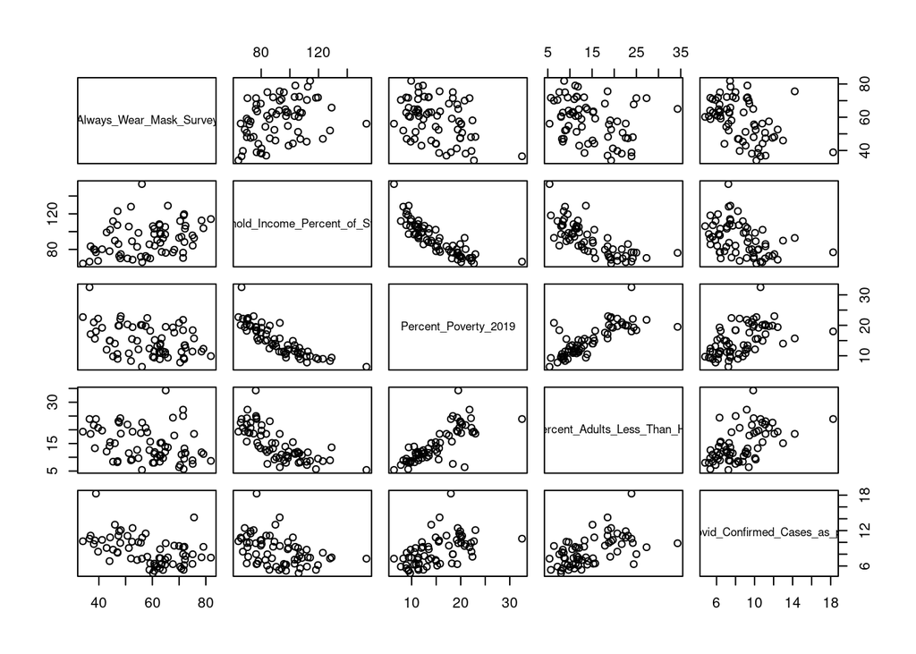

```r
plot(data_ord_base)
```

inertia is like variance but for a two way variable; inertia is sum of eigenvalues (look at proportion explained to see how much is explained in first direction, etc./ cumulative, after third, 98% of degradation etc. )

```r
# Enviromental variables dataset - data_ord_env
data_ord_env_county <- raw[raw$State_Name=="Florida", ]
data_ord_env_county <- data_ord_env_county[, c(2, 10, 18, 19, 25, 15)]

data_ord_env <- data_ord_env_county
data_ord_env$Civilian_Labor_Force_2019_as_pct <- 100*data_ord_env$Civilian_Labor_Force_2019_as_pct

data_ord_env1 <- data_ord_env
data_ord_env <- data_ord_env1[,-1]
rownames(data_ord_env) <- data_ord_env1[,1] # rownames are county names

dim(data_ord_env)
```

```
## [1] 67  5
```

```r
head(data_ord_env)
```

```
##          Unemployment_Rate_2019 Death_Rate_2019 Birth_Rate_2019
## Alachua                     2.9             7.7            10.3
## Baker                       3.1             9.5            11.2
## Bay                         3.9            11.0            12.3
## Bradford                    3.1            12.5            10.2
## Brevard                     3.2            12.5             8.8
## Broward                     3.0             8.2            11.2
##          Civilian_Labor_Force_2019_as_pct Percent_Adults_Bachelors_or_Higher
## Alachua                          51.74526                               42.5
## Baker                            40.57515                               13.4
## Bay                              48.21556                               22.8
## Bradford                         39.22556                               10.6
## Brevard                          47.19508                               29.3
## Broward                          53.28404                               31.9
```

# 1

**Fit Correspondence Analysis to your data.**

All columns of `data_ord_base` contains the variable data. Correspondence analysis is performed using the `cca()` function.

```r
# No negative data anyways
# data_ord_base <- data_ord_base[apply(data_ord_base, 1, sum) > 0, ]

#Perform correspondence analysis
data_ord_base_ca <- cca(data_ord_base)

# inertia is measure of departure from ind model; if no relationships from rows and columns; in this case, household income, percent poverty are related; other variables are not so strongly related; if inertia smaller - less structure to data in 5-D
```

# 2

**Discuss the inertia, make a two dimensional plot of the first two CA directions.**

```r
summary(data_ord_base_ca)
```

```
##
## Call:
## cca(X = data_ord_base)
##
## Partitioning of scaled Chi-square:
##               Inertia Proportion
## Total         0.05033          1
## Unconstrained 0.05033          1
##
## Eigenvalues, and their contribution to the scaled Chi-square
##
## Importance of components:
##                           CA1      CA2      CA3      CA4
## Eigenvalue            0.03606 0.009955 0.002521 0.001793
## Proportion Explained  0.71649 0.197808 0.050087 0.035616
## Cumulative Proportion 0.71649 0.914297 0.964384 1.000000
##
## Scaling 2 for species and site scores
## * Species are scaled proportional to eigenvalues
## * Sites are unscaled: weighted dispersion equal on all dimensions
##
##
## Species scores
##
##                                                          CA1      CA2       CA3
## Always_Wear_Mask_Survey                             -0.04389 -0.14340  0.002602
## Median_Household_Income_Percent_of_State_Total_2019 -0.12367  0.07293 -0.005506
## Percent_Poverty_2019                                 0.36607  0.01375  0.119450
## Percent_Adults_Less_Than_HS                          0.43620  0.01442 -0.127072
## Covid_Confirmed_Cases_as_pct                         0.23445  0.14590  0.048594
##                                                          CA4
## Always_Wear_Mask_Survey                              0.01398
## Median_Household_Income_Percent_of_State_Total_2019 -0.01211
## Percent_Poverty_2019                                -0.06152
## Percent_Adults_Less_Than_HS                         -0.01670
## Covid_Confirmed_Cases_as_pct                         0.17146
##
##
## Site scores (weighted averages of species scores)
##
```

[output cut: 53 more lines]

```
## Polk         -0.0173068 -0.63077 -0.47020 -0.120923
## Putnam        1.0882213 -0.83097  0.84041 -1.396901
## St. Johns    -1.8246946  1.91832 -0.46595 -0.771806
## St. Lucie    -0.4973983 -0.51158 -1.18380 -0.222083
## Santa Rosa   -0.9793112  1.73872  0.06881  0.120004
## Sarasota     -1.3034658 -0.42690 -0.25311  0.107948
## Seminole     -1.4009072 -0.32091  0.34367 -0.478166
## Sumter       -1.1177304 -0.06506 -0.32542 -0.421412
## Suwannee      0.8290661  1.75865 -0.30903  0.183506
## Taylor        1.4076618  0.46177 -0.43854  0.710780
## Union         1.0743577  0.92255 -0.77718 -0.237763
## Volusia      -0.5157772 -0.59935  0.52913 -0.612641
## Wakulla      -0.3710730  1.56935 -0.22170  0.039781
## Walton       -0.6230454  1.06728 -0.38047  0.383858
## Washington    1.0322373 -0.42952  0.54986  0.195862
```

In the “Proportion Explained” row, we can see that first CA direction explains 0.71649 (~72%) of the relation. The “Cumulative Proportion” by the second CA direction is 0.914297; hence, the first and second CA directions explain the vast majority of total inertia. The third and fourth CA directions have significantly smaller “Proportion Explained” values

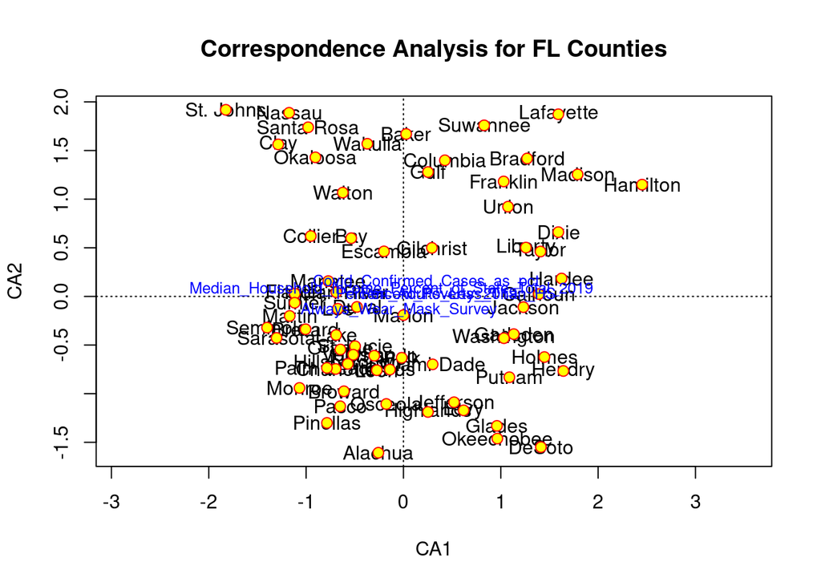

```r
#plot results
plot(data_ord_base_ca, main = "Correspondence Analysis for FL Counties", type = "n")
text(data_ord_base_ca, dis = "wa", labels = rownames(data_ord_base))
points(data_ord_base_ca, pch = 21, col = "red", bg = "yellow", cex = 1.2)
text(data_ord_base_ca, "species", col = "blue", cex = 0.8)
```

Add environmental variables.

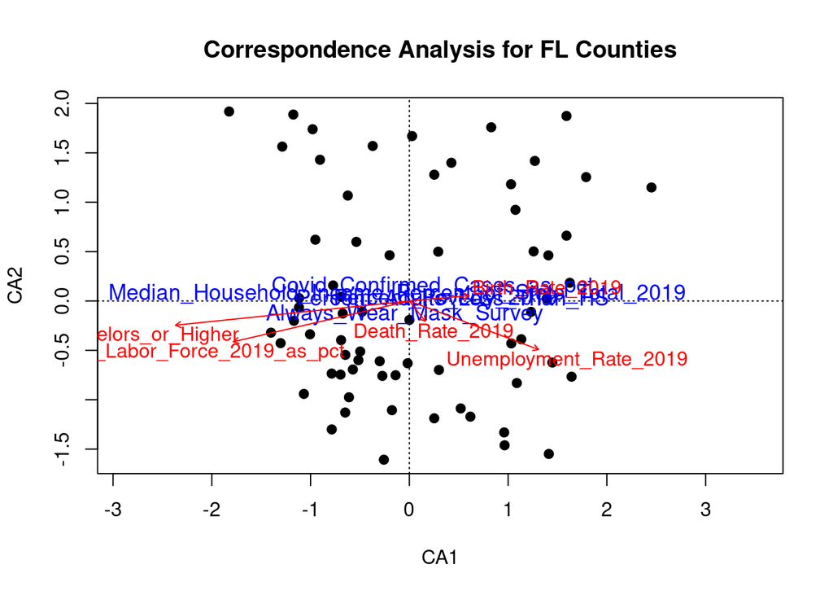

```r
plot(data_ord_base_ca, main = "Correspondence Analysis for FL Counties", type = "n")
points(data_ord_base_ca, pch = 19, col = "black", cex = 1)
text(data_ord_base_ca, "species", col = "blue", cex = 1.1)
#add environmental variables
fit <- envfit(data_ord_base_ca, data_ord_env, permutations = 1000)
plot(fit, col = "red", lwd = 3)
```

```r
#get significance - all environmental variables are significant
fit
```

```
##
## ***VECTORS
##
##                                         CA1      CA2     r2   Pr(>r)
## Unemployment_Rate_2019              0.93609 -0.35176 0.2400 0.001998 **
## Death_Rate_2019                     0.61828 -0.78596 0.0084 0.790210
## Birth_Rate_2019                     0.99605  0.08877 0.0450 0.228771
## Civilian_Labor_Force_2019_as_pct   -0.97424 -0.22551 0.4110 0.000999 ***
## Percent_Adults_Bachelors_or_Higher -0.99468 -0.10305 0.6962 0.000999 ***
## ---
## Signif. codes:  0 '***' 0.001 '**' 0.01 '*' 0.05 '.' 0.1 ' ' 1
## Permutation: free
## Number of permutations: 1000
```

We can see that all environmental variables are significant (p < 0.05) except `Birth_Rate_2019` and `Death_Rate_2019`. We will omit these variables from the environmental variable dataset for future analyses.

```r
data_ord_env <- subset(data_ord_env, select=-2)
data_ord_env <- subset(data_ord_env, select=-2)
```

This plot is somewhat hard to read, so we try detrended correspondence analysis. This is even harder to read. DCA uses the `decorana()` function.

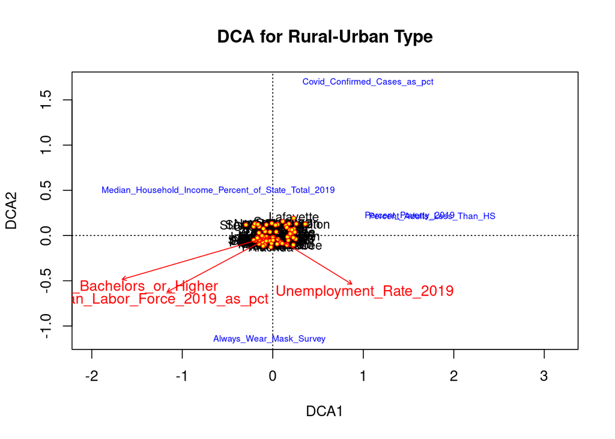

```r
#detrended correspondence analysis
data_ord_base_dca <- decorana(data_ord_base)
plot(data_ord_base_dca, main = "DCA for Rural-Urban Type", type = "n")
text(data_ord_base_dca, display = c("sites"), labels = rownames(data_ord_base), cex = 0.86)
points(data_ord_base_dca, pch = 21, col = "red", bg = "yellow", cex = 0.6)
text(data_ord_base_dca, "species", col = "blue", cex = 0.6)

#add environmental variables
fit <- envfit(data_ord_base_dca, data_ord_env, permutations = 1000)
plot(fit, col = "red", lwd = 3)
```

# 3

**Comment on whether or not there is any evidence of ‘data snaking’ in higher dimensional space.**

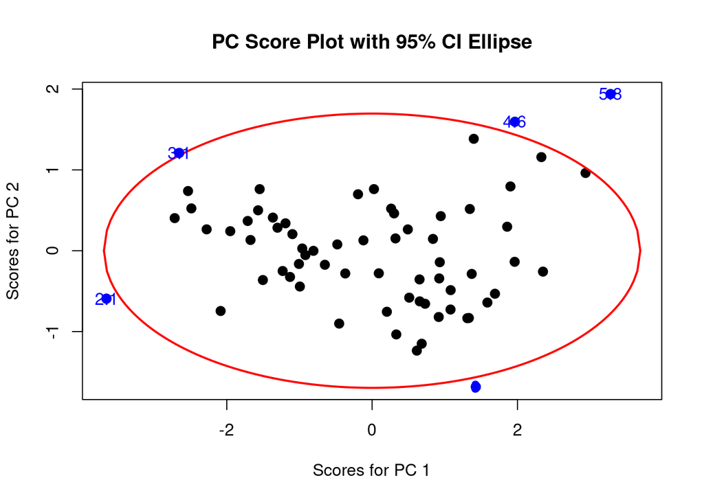

```r
pc1 <- princomp(data_ord_env, cor=TRUE)

source("http://reuningscherer.net/multivariate/r/ciscoreplot.R.txt")
ciscoreplot(pc1,c(1,2),data_ord_env[,1])
```

There is no evidence of data snaking in higher dimensional space. Evidence of snaking would be a PCA score plot that looks like a horseshoe. However, the above scoreplot appears random and therefore does not indicate data snaking.

# 4

**In a few sentences, describe what you conclude from your plot.**

From our first plot in (2) of the first two CA directions, we should be able to find which counties are similar and what are the columns on which they are similar. Overall, the counties seem evenly and randomly scattered between the 4 quadrants- we do not note rows near columns, so there is not association not accounted for by the independence model. Generally, the first correspondence axis is associated with low income and low education and high COVID-19 rates, while the second correspondence axis is associated primarily with poor masking behaviors and high COVID-19 rates, perhaps indicating two different types of counties that are associated with high COVID-19 rates (those in poorer, disadvantaged areas and also those with poor masking behaviors). As one may expect, the percent poverty and percent of adults with less than a high school degree point in the same direction, while the median household income points in the opposite direction.

# 5

**Perform Multidimensional Scaling (metric or non-metric) for 1, 2, and 3 dimensions.**

```r
results <- matrix(NA, 21, 5)
#j is number of dimensions to try
for (j in 1:5){
  for (i in 1:20){
    temp <- data_ord_base[shuffle(nrow(data_ord_base)), 1]
    for (k in 2:12) { temp <- cbind(temp, data_ord_base[shuffle(nrow(data_ord_base)), k]) }
    #store stress
    results[i, j] <- metaMDS(temp, k = j, distance = "euclidean")$stress
  }
  results[21, j] <- metaMDS(data_ord_base, k = j, distance = "euclidean")$stress
}

# Note: results are hidden (too long)
```

# 6

**Discuss the stress (or SStress) of each dimensional solution. Make a scree plot if you’re able.**

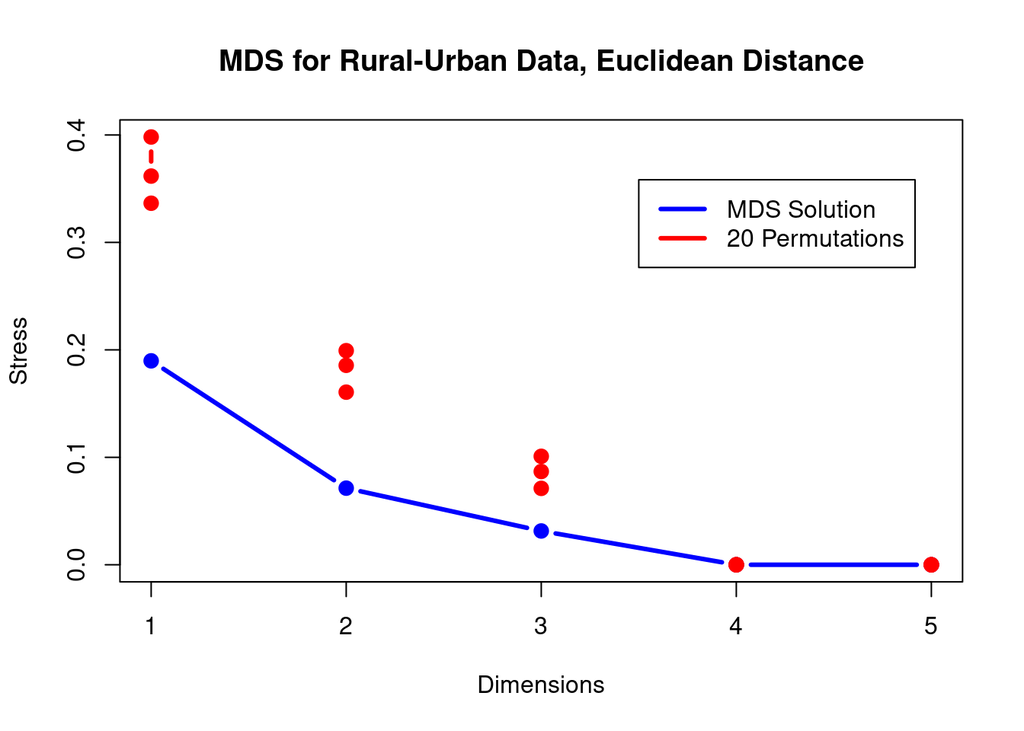

```r
#plot stress results

plot(c(1:5), results[21, ], type = "b", col = "blue", lwd = 3,
     ylim = c(0, max(results)), xlab = "Dimensions", ylab = "Stress", pch = 19,
     main = "MDS for Rural-Urban Data, Euclidean Distance")
mins <- apply(results[1:20, ], 2, min)
maxs <- apply(results[1:20, ], 2, max)
meds <- apply(results[1:20, ], 2, median)

for (i in 1:5){
  points(rep(i, 3), c(mins[i], meds[i], maxs[i]), type = "b", col = "red", lwd = 3, pch = 19)
}
legend(3.5, (.9*max(results)), c("MDS Solution", "20 Permutations"), lwd = 3, col = c("blue", "red"))
```

After performing multidimensional scaling for 1-5 dimensions, the above scree plot for stress illustrates an elbow at 2 dimensions. This stress level is below 10% and indicates a good fit. For 3 dimensions, the stress is below 5% and indicates an excellent fit.

Stress is a measure of the difference between actual pairwise distances and calculated reference distances; a lower stress indicates a better fit. As the dimensions exceeds that of the data (for 4 and 5 dimensions), the stress goes to 0.

# 7

**Make a two dimensional plot of your MDS results.**

```r
data_ord_base.mds2 <- metaMDS(data_ord_base, k = 2, distance = "euclidean")
```

```
## Square root transformation
## Wisconsin double standardization
## *** Solution reached
```

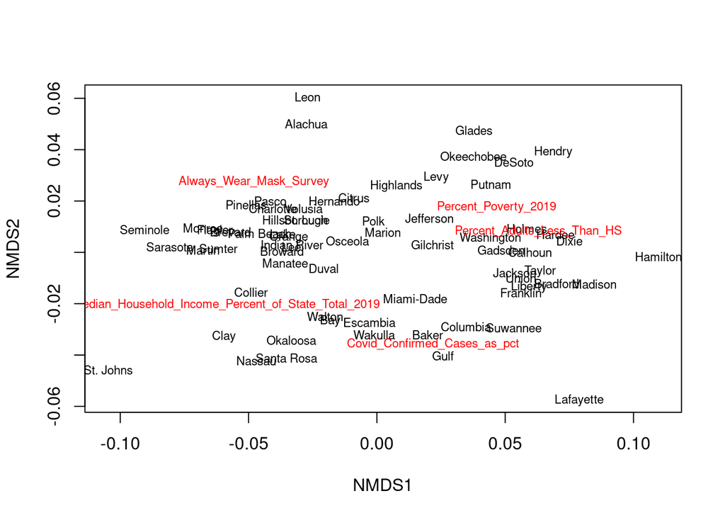

```r
plot(data_ord_base.mds2, type = "t")
```

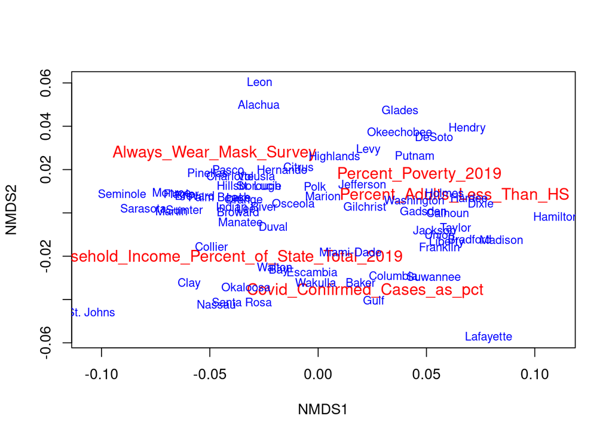

```r
#more refined plot
fig <- ordiplot(data_ord_base.mds2, type = "none", cex = 1.1)
text(fig, "species", col = "red", cex = 1.1)
text(fig, "sites", col = "blue", cex = 0.8)
```

# 8

**If possible, overlay some other continuous variable(s) to interpret your ordination axes. Calculate p-values for the overlaid additional variable(s). If you can, get some non-linear wireplots of the these overlaid variables (see examples online in R).**

We can also add environmental variables to our plot.

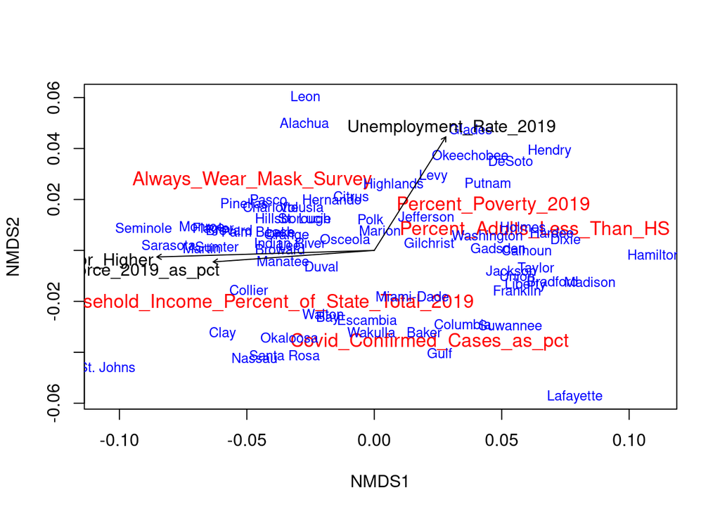

```r
fig <- ordiplot(data_ord_base.mds2, type = "none", cex = 1.1)
text(fig, "species", col = "red", cex = 1.1)
text(fig, "sites", col = "blue", cex = 0.8)

fit <- envfit(data_ord_base.mds2, data_ord_env, permutations = 1000)
plot(fit, col = "black", lwd = 3)
```

```r
fit <- envfit(data_ord_base_ca, data_ord_env, permutations = 1000)
fit
```

```
##
## ***VECTORS
##
##                                         CA1      CA2     r2   Pr(>r)
## Unemployment_Rate_2019              0.93609 -0.35176 0.2400 0.000999 ***
## Civilian_Labor_Force_2019_as_pct   -0.97424 -0.22551 0.4110 0.000999 ***
## Percent_Adults_Bachelors_or_Higher -0.99468 -0.10305 0.6962 0.000999 ***
## ---
## Signif. codes:  0 '***' 0.001 '**' 0.01 '*' 0.05 '.' 0.1 ' ' 1
## Permutation: free
## Number of permutations: 1000
```

The three overlaid continuous variables above are all significant with p<0.05.

```r
mds4 <- metaMDS(data_ord_env, distance="euclidean", k=4)
```

```
## Square root transformation
## Wisconsin double standardization
## *** No convergence -- monoMDS stopping criteria:
##     20: no. of iterations >= maxit
```

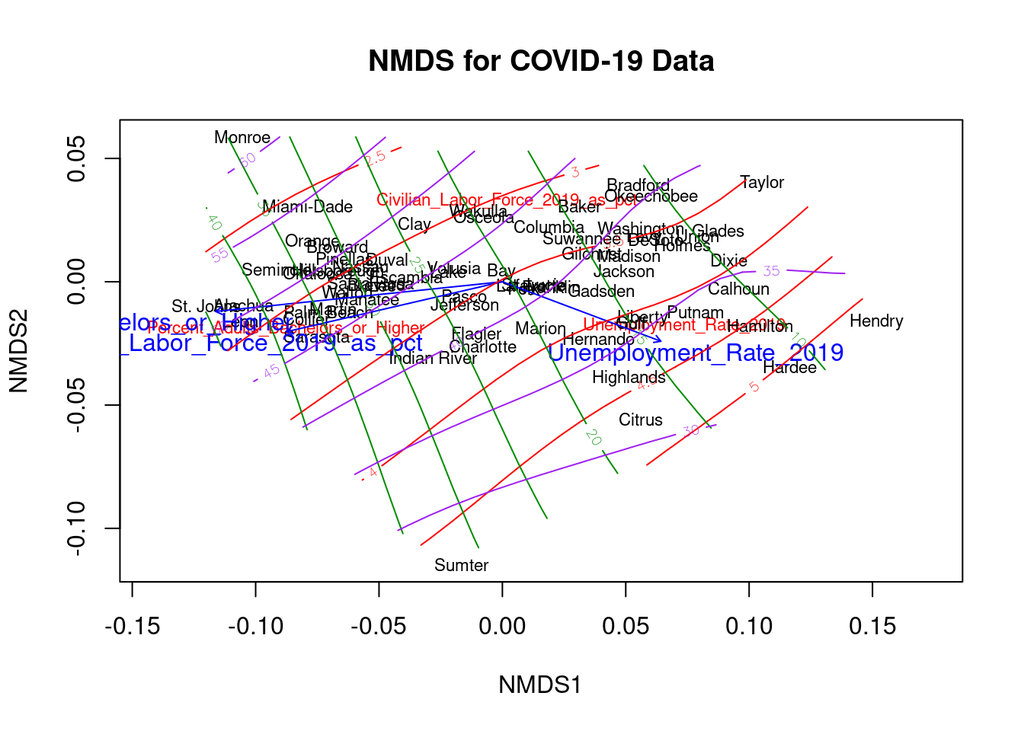

```r
fig <- ordiplot(mds4, type = "none", cex = 1.1, main = "NMDS for COVID-19 Data")
text(fig, "species", col = "red", cex = 0.7)
text(fig, "sites", col = "black", cex = 0.7)
plot(fit)
tmp1 <- with(data_ord_env, ordisurf(mds4, Unemployment_Rate_2019, add = TRUE))
tmp2 <- with(data_ord_env, ordisurf(mds4, Percent_Adults_Bachelors_or_Higher, add = TRUE, col = "green4"))
tmp3 <- with(data_ord_env, ordisurf(mds4, Civilian_Labor_Force_2019_as_pct, add = TRUE, col = "purple"))
```

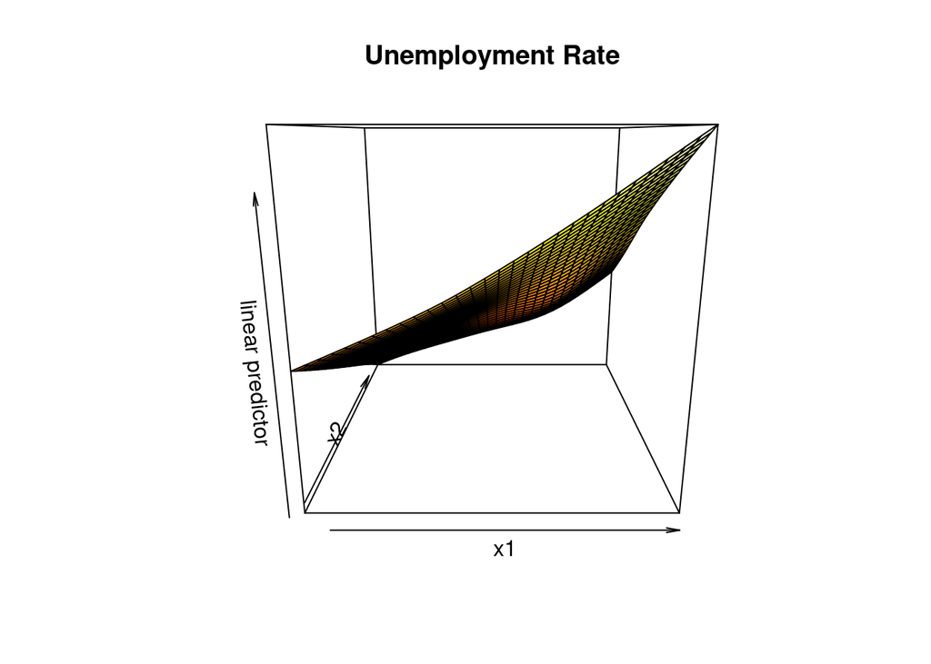

```r
vis.gam(tmp1, main = "Unemployment Rate")
```

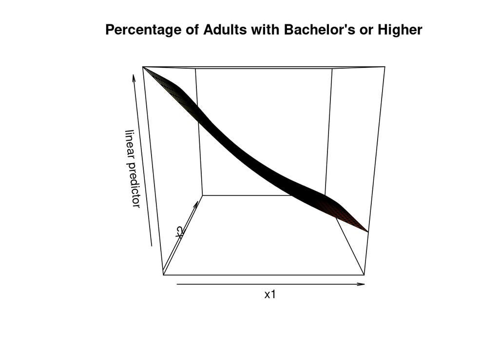

```r
vis.gam(tmp2, main = "Percentage of Adults with Bachelor's or Higher")
```

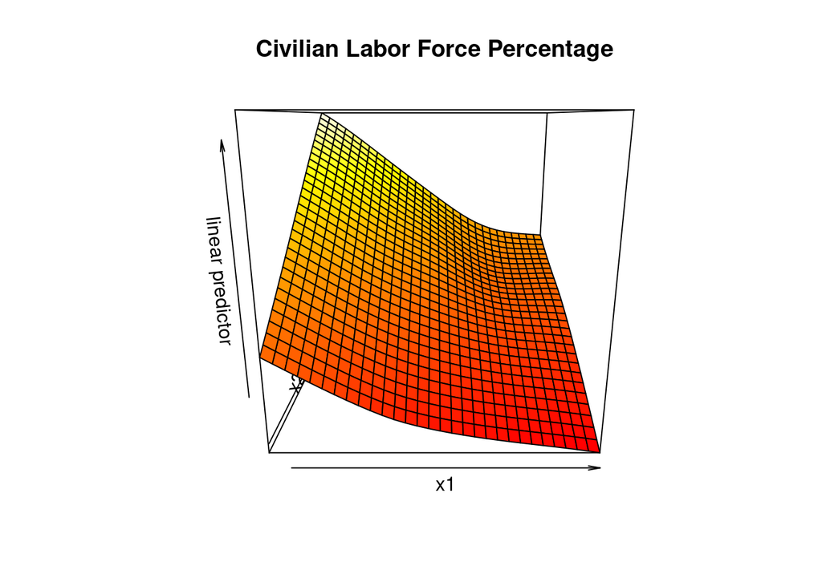

```r
vis.gam(tmp3, main = "Civilian Labor Force Percentage")
```

# 9

**Again, assuming you have at least one additional continuous variable, perform canonical correspondence analysis.**

As directed, here we’ll perform CCA – both with and without (or the other way around) the environmental variables.

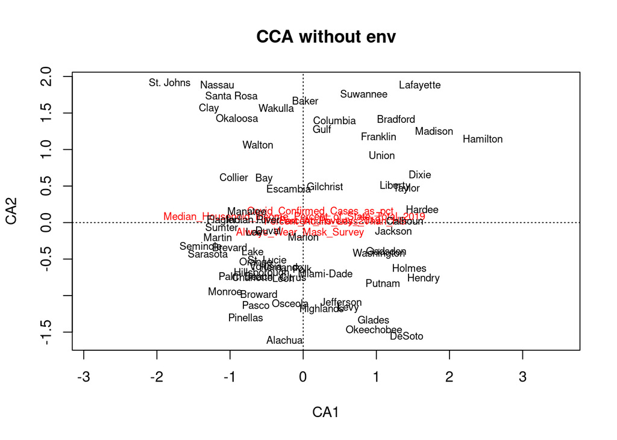

```r
data_ord_base_cca1 <- cca(data_ord_base, scale="FALSE")
data_ord_base_cca2 <- cca(data_ord_base, data_ord_env, scale="FALSE")
plot(data_ord_base_cca1, main="CCA without env")
```

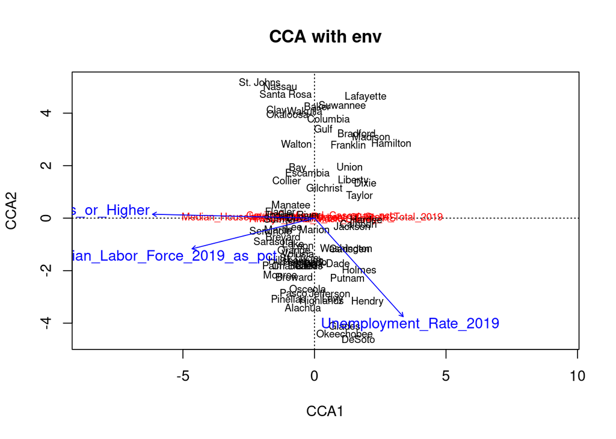

```r
plot(data_ord_base_cca2, main="CCA with env")
```

```r
#plot(data_ord_base_cca, main = "CCA for Rural-Urban Type", type = "n")
#points(data_ord_base_cca, pch = 19, col = "red", cex = 1)
#text(data_ord_base_cca, "species", col = "blue", cex = 0.7)
#text(data_ord_base_cca, display = c("sites"), labels = rownames(data_ord_base), cex = 0.5)

(fit_cca <- envfit(data_ord_base_cca2, data_ord_env, permutations=1000))
```

```
##
## ***VECTORS
##
##                                         CCA1      CCA2     r2   Pr(>r)
## Unemployment_Rate_2019              0.977760 -0.209739 0.2553 0.001998 **
## Civilian_Labor_Force_2019_as_pct   -0.997160 -0.075256 0.4131 0.000999 ***
## Percent_Adults_Bachelors_or_Higher -0.999830 -0.018480 0.7048 0.000999 ***
## ---
## Signif. codes:  0 '***' 0.001 '**' 0.01 '*' 0.05 '.' 0.1 ' ' 1
## Permutation: free
## Number of permutations: 1000
```

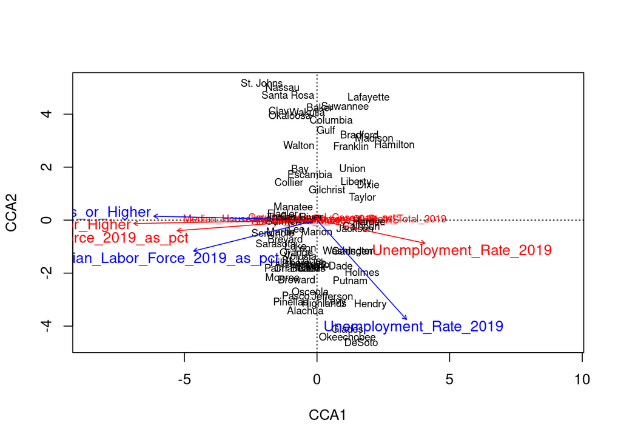

```r
plot(data_ord_base_cca2)
plot(fit_cca, col = "red", lwd = 3)
```

```r
summary(data_ord_base_cca2)
```

```
##
## Call:
## cca(X = data_ord_base, Y = data_ord_env, scale = "FALSE")
##
## Partitioning of scaled Chi-square:
##               Inertia Proportion
## Total         0.05033     1.0000
## Constrained   0.02673     0.5312
## Unconstrained 0.02360     0.4688
##
## Eigenvalues, and their contribution to the scaled Chi-square
##
## Importance of components:
##                          CCA1     CCA2      CCA3     CA1     CA2      CA3
## Eigenvalue            0.02517 0.001433 0.0001286 0.01225 0.00795 0.002016
## Proportion Explained  0.50014 0.028465 0.0025542 0.24348 0.15796 0.040061
## Cumulative Proportion 0.50014 0.528601 0.5311551 0.77463 0.93259 0.972652
##                            CA4
## Eigenvalue            0.001376
## Proportion Explained  0.027348
## Cumulative Proportion 1.000000
##
## Accumulated constrained eigenvalues
## Importance of components:
##                          CCA1     CCA2      CCA3
## Eigenvalue            0.02517 0.001433 0.0001286
## Proportion Explained  0.94160 0.053590 0.0048088
## Cumulative Proportion 0.94160 0.995191 1.0000000
##
## Scaling 2 for species and site scores
## * Species are scaled proportional to eigenvalues
## * Sites are unscaled: weighted dispersion equal on all dimensions
##
##
## Species scores
##
##                                                         CCA1     CCA2      CCA3
## Always_Wear_Mask_Survey                             -0.05278 -0.05184  0.004032
## Median_Household_Income_Percent_of_State_Total_2019 -0.09263  0.02673 -0.003443
## Percent_Poverty_2019                                 0.28361  0.01487 -0.020196
```

[output cut: 145 more lines]

```
## Suwannee      0.788376  0.307791  0.576808  0.23530 -1.765324 -0.34052
## Taylor        1.516638  0.180899  0.861904 -0.16838 -0.384565 -0.46401
## Union         1.519029  2.642363 -0.115282  0.26188  0.379401 -0.54734
## Volusia      -0.128104 -0.398469  0.452265  0.47984  0.739835  1.14598
## Wakulla       0.406747  0.785360  1.065397  1.52163 -0.774887  0.30464
## Walton       -0.547063  1.422236 -0.247075  0.48687 -0.468831 -0.75593
## Washington    1.105397  0.681665  0.482510 -0.50963  0.689445  0.59098
##
##
## Biplot scores for constraining variables
##
##                                       CCA1     CCA2     CCA3 CA1 CA2 CA3
## Unemployment_Rate_2019              0.5473 -0.60888 -0.57427   0   0   0
## Civilian_Labor_Force_2019_as_pct   -0.7554 -0.18958  0.62725   0   0   0
## Percent_Adults_Bachelors_or_Higher -0.9991  0.02401 -0.03542   0   0   0
```

# 10